# This is a project to build a model to identify if a person has income more than 50K a year or not.

```python
import pandas as pd
import numpy as np
```

```python
import matplotlib.pyplot as plt
import missingno
import seaborn as sns
```

```python
import math, time, random, datetime
```

```python
from sklearn.model_selection import train_test_split
```

```python
import catboost
```

```python
from sklearn import model_selection, tree, preprocessing, metrics, linear_model
from sklearn.svm import LinearSVC
from sklearn.ensemble import GradientBoostingClassifier
from sklearn.linear_model import LinearRegression, LogisticRegression, SGDClassifier
from sklearn.tree import DecisionTreeClassifier
```

```python
df = pd.read_csv('adult.csv')
```

```python
df.head()
```

|  | age | workclass | fnlwgt | education | education.num | marital.status | occupation | relationship | race | sex | capital.gain | capital.loss | hours.per.week | native.country | income |
| --- | --- | --- | --- | --- | --- | --- | --- | --- | --- | --- | --- | --- | --- | --- | --- |
| 0 | 90 | ? | 77053 | HS-grad | 9 | Widowed | ? | Not-in-family | White | Female | 0 | 4356 | 40 | United-States | <=50K |
| 1 | 82 | Private | 132870 | HS-grad | 9 | Widowed | Exec-managerial | Not-in-family | White | Female | 0 | 4356 | 18 | United-States | <=50K |
| 2 | 66 | ? | 186061 | Some-college | 10 | Widowed | ? | Unmarried | Black | Female | 0 | 4356 | 40 | United-States | <=50K |
| 3 | 54 | Private | 140359 | 7th-8th | 4 | Divorced | Machine-op-inspct | Unmarried | White | Female | 0 | 3900 | 40 | United-States | <=50K |
| 4 | 41 | Private | 264663 | Some-college | 10 | Separated | Prof-specialty | Own-child | White | Female | 0 | 3900 | 40 | United-States | <=50K |

```python
df.shape
```

```
(32561, 15)
```

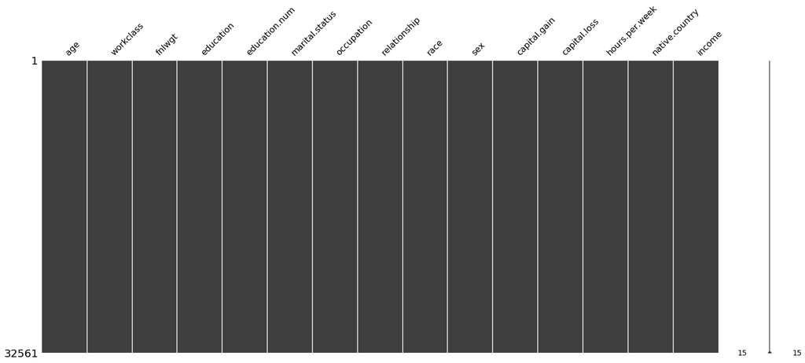

```python
missingno.matrix(df)
```

```python
df['income'].value_counts()
```

```
<=50K    24720
>50K      7841
Name: income, dtype: int64
```

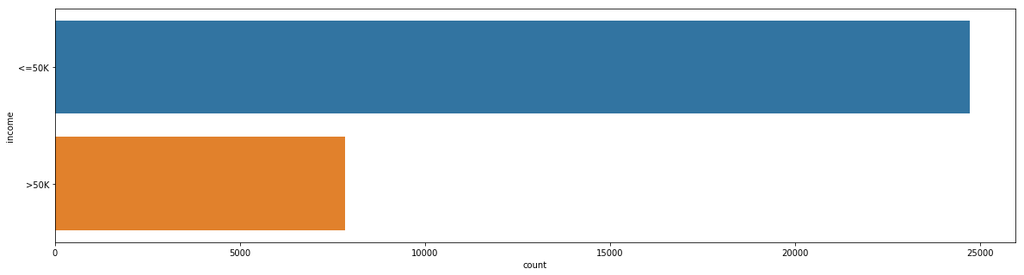

```python
plt.figure(figsize=(20, 5))
sns.countplot(y="income", data=df);
```

# Age column

First we define a function to categorize the ages of the persons. This is because it will be easier to plot the values and also see a pattern between age and income.

```python
def age_func(x):
    if x <= 10:
        return 10
    elif x > 10 and x <= 20:
        return 20
    elif x > 20 and x <= 30:
        return 30
    elif x > 30 and x <= 40:
        return 40
    elif x > 40 and x <= 50:
        return 50
    elif x > 50 and x <= 60:
        return 60
    elif x > 60 and x <= 70:
        return 70
    elif x > 70 and x <= 80:
        return 80
    elif x > 80 and x <= 90:
        return 90
    else:
        return 100
```

```python
df['age'] = df['age'].apply(age_func)
```

```python
df['age'].value_counts()
```

```
40    8546
30    8162
50    6983
60    4128
20    2410
70    1792
80     441
90      99
Name: age, dtype: int64
```

```python
def plot_count_dist(data, df, label_column, target_column, figsize=(20, 5), use_df=False):
        if use_df:
            fig = plt.figure(figsize=figsize)
            plt.subplot(1, 2, 1)
            sns.countplot(y=target_column, data=df);
            plt.subplot(1, 2, 2)
            sns.distplot(data.loc[data[label_column] == 1][target_column], kde_kws={"label": "Below 50K"});
            sns.distplot(data.loc[data[label_column] == 0][target_column], kde_kws={"label": "Above 50K"});
        else:
            fig = plt.figure(figsize=figsize)
            plt.subplot(1, 2, 1)
            sns.countplot(y=target_column, data=data);
            plt.subplot(1, 2, 2)
            sns.distplot(data.loc[data[label_column] == 1][target_column], kde_kws={"label": "Below 50K"});
            sns.distplot(data.loc[data[label_column] == 0][target_column], kde_kws={"label": "Above 50K"});
```

```python
df["income"] = df.income.replace({"<=50K":0, ">50K":1})
```

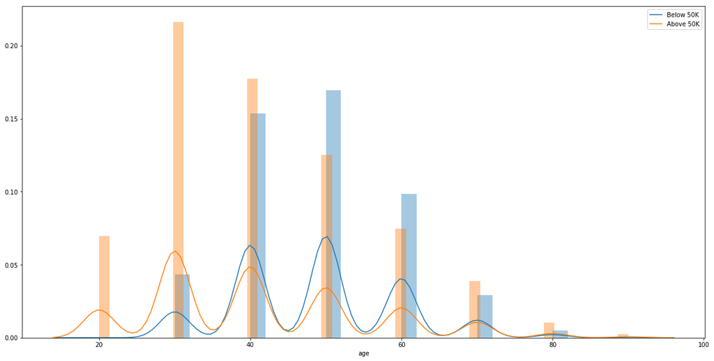

```python
fig = plt.figure(figsize=(20, 10))
sns.distplot(df.loc[df["income"] == 1]["age"], kde_kws={"label": "Below 50K"});
sns.distplot(df.loc[df["income"] == 0]["age"], kde_kws={"label": "Above 50K"});
```

The graph above shows a definite pattern which tells us that the persons whos age is between 40 years to 60 years have the most chance of having income more than 50K a year.

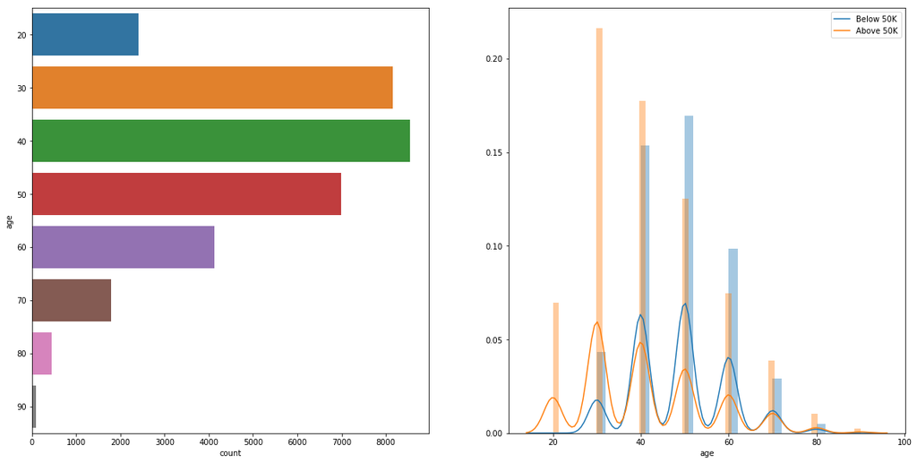

```python
plot_count_dist(df, df=df, label_column="income", target_column="age", figsize=(20, 10))
```

# Education column

As expected there is a positive linear relation between people who have higher education and people who have higher income.

```python
df['education'].value_counts()
```

```
HS-grad         10501
Some-college     7291
Bachelors        5355
Masters          1723
Assoc-voc        1382
11th             1175
Assoc-acdm       1067
10th              933
7th-8th           646
Prof-school       576
9th               514
12th              433
Doctorate         413
5th-6th           333
1st-4th           168
Preschool          51
Name: education, dtype: int64
```

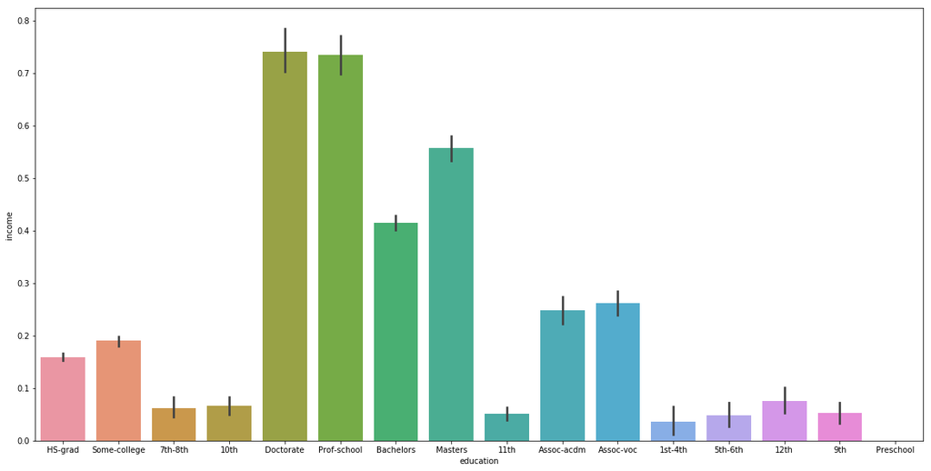

```python
plt.figure(figsize=(20,10))
sns.barplot(x="education", y="income", data=df)
```

# Workclass

```python
df["workclass"].value_counts()
```

```
Private             22696
Self-emp-not-inc     2541
Local-gov            2093
?                    1836
State-gov            1298
Self-emp-inc         1116
Federal-gov           960
Without-pay            14
Never-worked            7
Name: workclass, dtype: int64
```

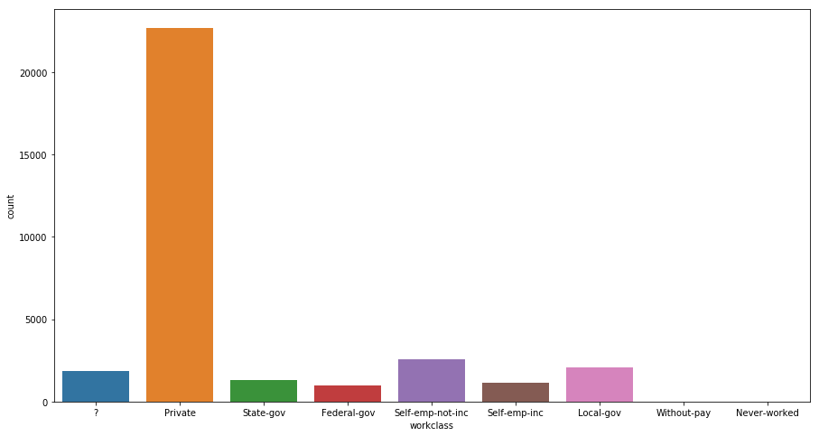

```python
plt.figure(figsize=(15, 8))
sns.countplot(df["workclass"])
```

The Above graph shows that most of the people in survey worked in Private sector.

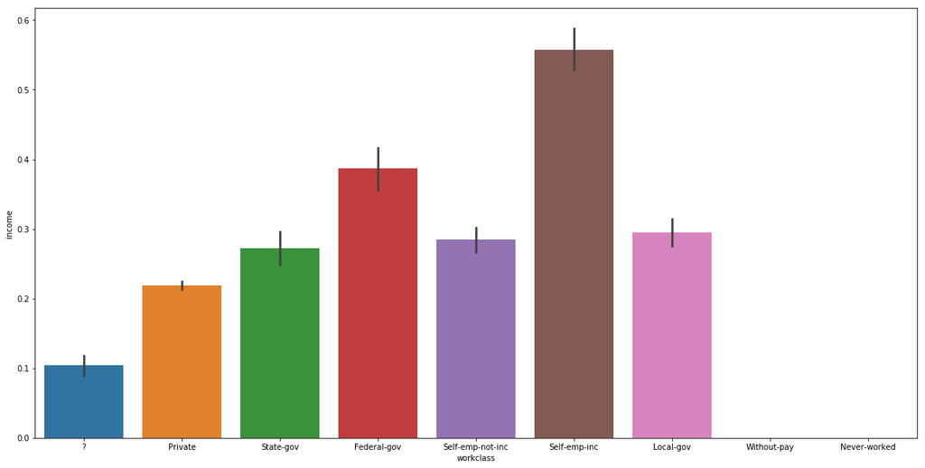

```python
plt.figure(figsize=(20, 10))
sns.barplot(x = "workclass", y = "income", data=df)
```

The above graph shows in which class you have more probability of income more than 50K and in which class not.

# Education num

Same as education but in this we can have a numerical representation of the education.

```python
df["education.num"].value_counts()
```

```
9     10501
10     7291
13     5355
14     1723
11     1382
7      1175
12     1067
6       933
4       646
15      576
5       514
8       433
16      413
3       333
2       168
1        51
Name: education.num, dtype: int64
```

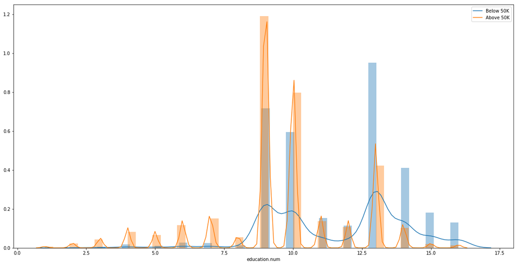

```python
fig = plt.figure(figsize=(20, 10))
sns.distplot(df.loc[df["income"] == 1]["education.num"], kde_kws={"label": "Below 50K"});
sns.distplot(df.loc[df["income"] == 0]["education.num"], kde_kws={"label": "Above 50K"});
```

# Marital Status

```python
df["marital.status"].value_counts()
```

```
Married-civ-spouse       14976
Never-married            10683
Divorced                  4443
Separated                 1025
Widowed                    993
Married-spouse-absent      418
Married-AF-spouse           23
Name: marital.status, dtype: int64
```

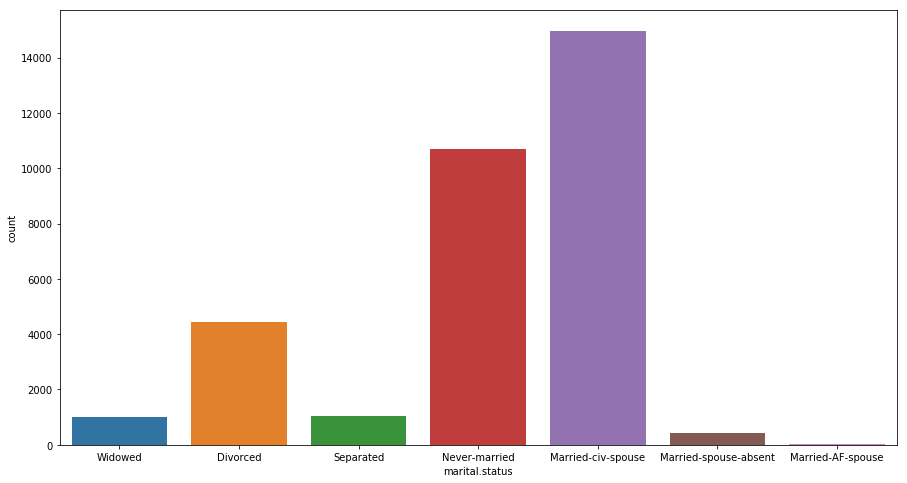

```python
plt.figure(figsize = (15,8))
sns.countplot(df["marital.status"])
```

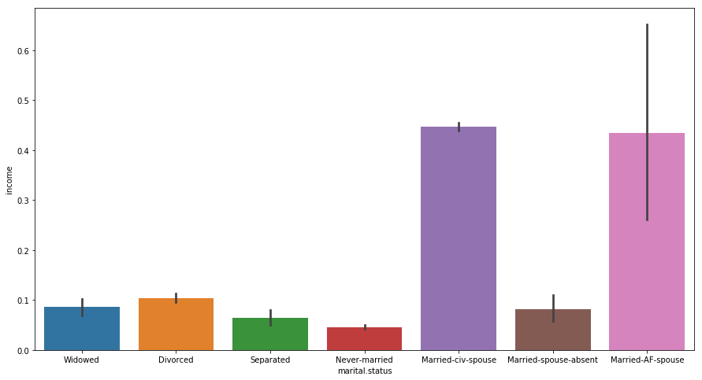

```python
plt.figure(figsize=(15,8))
sns.barplot(x='marital.status', y='income', data=df)
```

This graph shows that being married significantly increases the chances of having income more than 50K annually.

# Occupation

Occupation is also a mojor factor in determining whether a person has income higher than 50K or not.

```python
df["occupation"].value_counts()
```

```
Prof-specialty       4140
Craft-repair         4099
Exec-managerial      4066
Adm-clerical         3770
Sales                3650
Other-service        3295
Machine-op-inspct    2002
?                    1843
Transport-moving     1597
Handlers-cleaners    1370
Farming-fishing       994
Tech-support          928
Protective-serv       649
Priv-house-serv       149
Armed-Forces            9
Name: occupation, dtype: int64
```

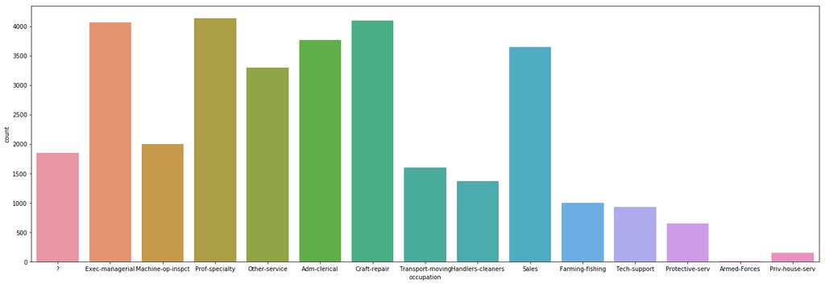

```python
plt.figure(figsize = (24,8))
sns.countplot(df["occupation"])
```

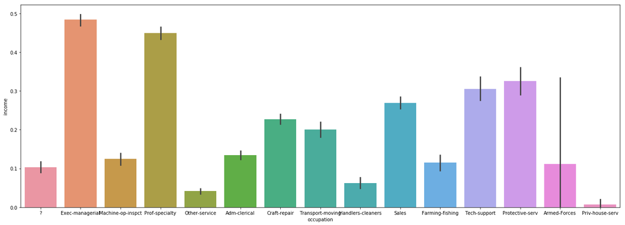

```python
plt.figure(figsize=(23,8))
sns.barplot(x='occupation', y='income', data=df)
```

This graph shows that Executive Managerial profession has the best chance of having a income more than 50K.

# Relationship

```python
df["relationship"].value_counts()
```

```
Husband           13193
Not-in-family      8305
Own-child          5068
Unmarried          3446
Wife               1568
Other-relative      981
Name: relationship, dtype: int64
```

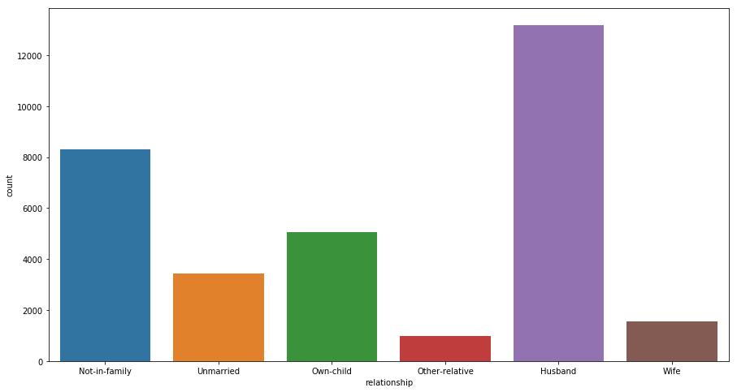

```python
plt.figure(figsize = (15,8))
sns.countplot(df["relationship"])
```

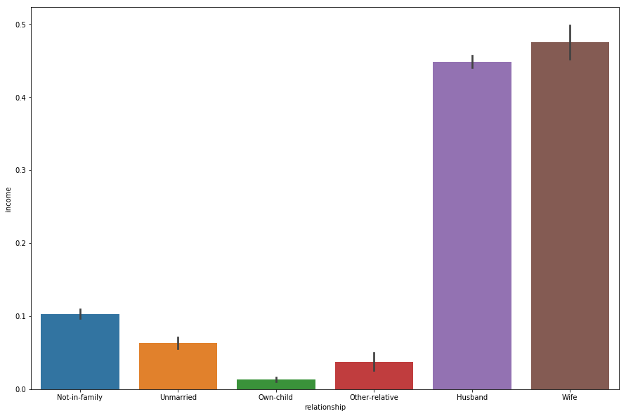

```python
plt.figure(figsize=(15,10))
sns.barplot(x='relationship', y='income', data=df)
```

# Race

```python
df["race"].value_counts()
```

```
White                 27816
Black                  3124
Asian-Pac-Islander     1039
Amer-Indian-Eskimo      311
Other                   271
Name: race, dtype: int64
```

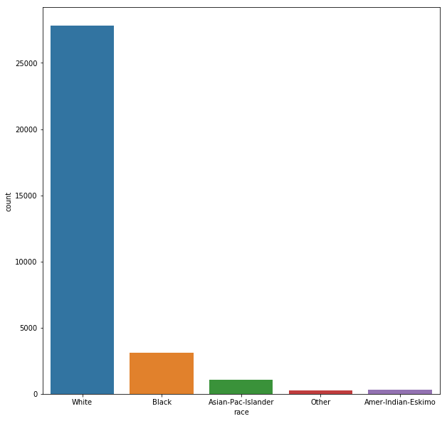

```python
plt.figure(figsize = (10, 10))
sns.countplot(df["race"])
```

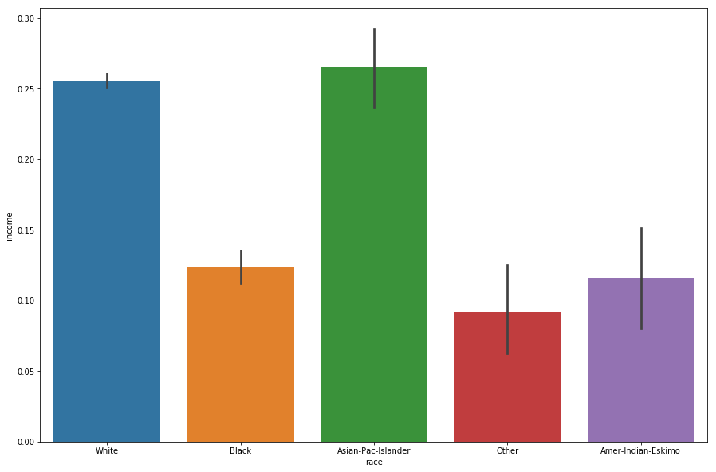

```python
plt.figure(figsize=(15,10))
sns.barplot(x='race', y='income', data=df)
```

This graph shows that whites and Asian-Pacific Islander both have significantly higher chances of having income more than 50K than other races.

# Gender

In this dataset no. of males are almost double as no. of females

```python
df["sex"] = df.sex.replace({"Female": 1, "Male": 0})
```

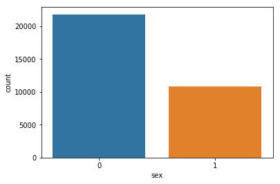

```python
sns.countplot(df["sex"])
```

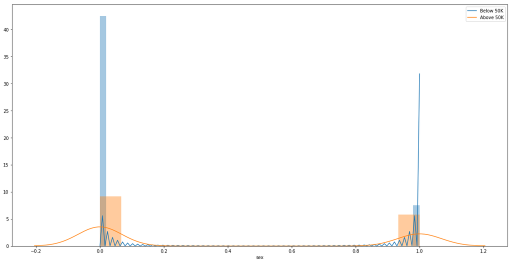

```python
fig = plt.figure(figsize=(20, 10))
sns.distplot(df.loc[df["income"] == 1]["sex"], kde_kws={"label": "Below 50K"});
sns.distplot(df.loc[df["income"] == 0]["sex"], kde_kws={"label": "Above 50K"});
```

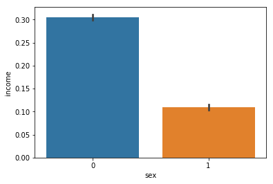

```python
sns.barplot(x="sex", y="income", data=df)
```

Males also have advantage over females for having a chance to have higher income than 50K.

# Capital Gain

```python
df["capital.gain"].value_counts()
```

```
0        29849
15024      347
7688       284
7298       246
99999      159
         ...
4931         1
1455         1
6097         1
22040        1
1111         1
Name: capital.gain, Length: 119, dtype: int64
```

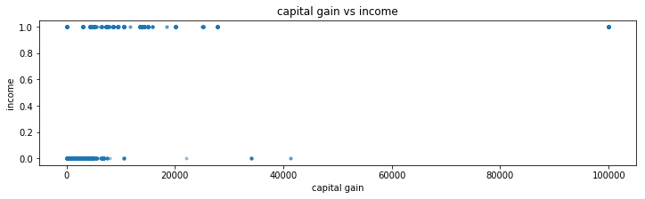

```python
plt.figure(figsize=(12,3))
plt.xlabel("capital gain")
plt.ylabel('income')
plt.title('capital gain vs income')
plt.plot(df['capital.gain'],df['income'],'.',alpha = 0.4)
```

# Capital Loss

```python
df["capital.loss"].value_counts()
```

```
0       31042
1902      202
1977      168
1887      159
1848       51
        ...
1411        1
1539        1
2472        1
1944        1
2201        1
Name: capital.loss, Length: 92, dtype: int64
```

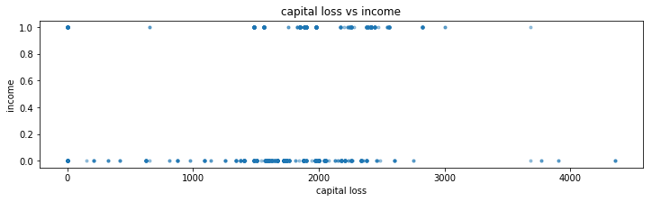

```python
plt.figure(figsize=(12,3))
plt.xlabel("capital loss")
plt.ylabel('income')
plt.title('capital loss vs income')
plt.plot(df['capital.loss'],df['income'],'.',alpha = 0.4)
```

# Hours per Week

As we can see that almost half of the persons in the survey work an exact of 40 hours.

```python
df["hours.per.week"].value_counts()
```

```
40    15217
50     2819
45     1824
60     1475
35     1297
      ...
92        1
94        1
87        1
74        1
82        1
Name: hours.per.week, Length: 94, dtype: int64
```

Hours per week people work are kind of all over the place so to make it better to fit in our model we will categorize it by making a function.

```python
def hours_func(x):
    if x <= 30:
        return 30
    elif x > 30 and x < 40:
        return 35
    elif x == 40:
        return 40
    elif x > 40 and x <= 50:
        return 50
    elif x > 50 and x <= 60:
        return 60
    else:
        return 75
```

```python
df["hours.per.week"] = df["hours.per.week"].apply(hours_func)
```

```python
df["hours.per.week"].value_counts()
```

```
40    15217
50     5938
30     5245
60     2533
35     2518
75     1110
Name: hours.per.week, dtype: int64
```

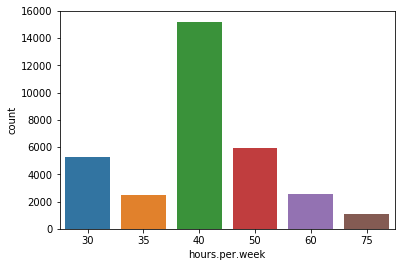

```python
sns.countplot(df["hours.per.week"])
```

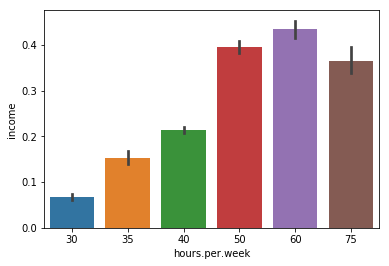

```python
sns.barplot(x="hours.per.week", y="income", data=df)
```

As imagined people who work more hours have more chance of having better income than people who work lesser hours.

# Native Country

As there are a lot of different countries of the surveyants, so we will try to categorize them by either their continents(like Europe) or a definite geographical part (like East Asia or Central America).

```python
df["native.country"].value_counts()
```

```
United-States                 29170
Mexico                          643
?                               583
Philippines                     198
Germany                         137
Canada                          121
Puerto-Rico                     114
El-Salvador                     106
India                           100
Cuba                             95
England                          90
Jamaica                          81
South                            80
China                            75
Italy                            73
Dominican-Republic               70
Vietnam                          67
Guatemala                        64
Japan                            62
Poland                           60
Columbia                         59
Taiwan                           51
Haiti                            44
Iran                             43
Portugal                         37
Nicaragua                        34
Peru                             31
France                           29
Greece                           29
Ecuador                          28
Ireland                          24
Hong                             20
Trinadad&Tobago                  19
Cambodia                         19
Thailand                         18
Laos                             18
Yugoslavia                       16
Outlying-US(Guam-USVI-etc)       14
Honduras                         13
Hungary                          13
Scotland                         12
Holand-Netherlands                1
Name: native.country, dtype: int64
```

```python
df["native.country"] = df["native.country"].replace({"Italy":"Europe", "Germany":"Europe", "Poland":"Europe", "Portugal":"Europe", "France":"Europe", "Greece":"Europe", "Ireland":"Europe", "Hungary":"Europe", "Scotland":"Europe", "Yugoslavia":"Europe", "Holand-Netherlands":"Europe"})
```

```python
df["native.country"] = df["native.country"].replace({"Trinadad&Tobago":"Central America", "Puerto-Rico":"Central America", "Honduras":"Central America", "Cuba":"Central America", "Peru":"Europe", "Nicaragua":"Europe", "Dominican-Republic":"Central America", "Haiti":"Central America", "El-Salvador":"Central America", "Guatemala":"Central America", "Jamaica":"Central America", "Equador":"Central America"})
```

```python
df["native.country"] = df["native.country"].replace({"Vietnam":"East Asia", "Taiwan":"East Asia", "Philippines":"East Asia", "Hong":"East Asia", "Cambodia":"East Asia", "Laos":"East Asia", "Thailand":"East Asia"})
```

```python
df["native.country"] = df["native.country"].replace({"Outlying-US(Guam-USVI-etc)":"Guam"})
```

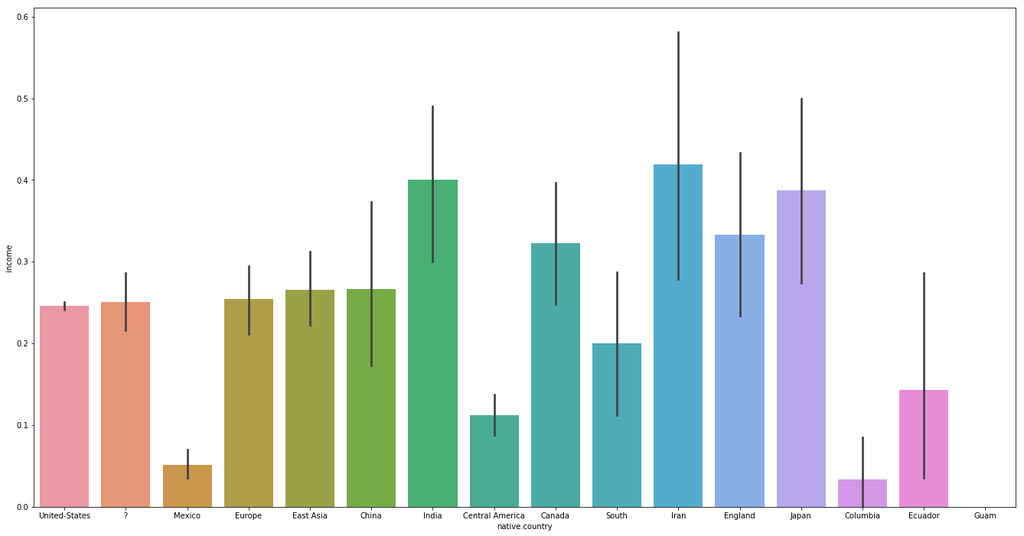

```python
plt.figure(figsize=(23, 12))
sns.barplot(x="native.country", y="income", data=df)
```

```python
df
```

|  | age | workclass | fnlwgt | education | education.num | marital.status | occupation | relationship | race | sex | capital.gain | capital.loss | hours.per.week | native.country | income |
| --- | --- | --- | --- | --- | --- | --- | --- | --- | --- | --- | --- | --- | --- | --- | --- |
| 0 | 90 | ? | 77053 | HS-grad | 9 | Widowed | ? | Not-in-family | White | 1 | 0 | 4356 | 40 | United-States | 0 |
| 1 | 90 | Private | 132870 | HS-grad | 9 | Widowed | Exec-managerial | Not-in-family | White | 1 | 0 | 4356 | 30 | United-States | 0 |
| 2 | 70 | ? | 186061 | Some-college | 10 | Widowed | ? | Unmarried | Black | 1 | 0 | 4356 | 40 | United-States | 0 |
| 3 | 60 | Private | 140359 | 7th-8th | 4 | Divorced | Machine-op-inspct | Unmarried | White | 1 | 0 | 3900 | 40 | United-States | 0 |
| 4 | 50 | Private | 264663 | Some-college | 10 | Separated | Prof-specialty | Own-child | White | 1 | 0 | 3900 | 40 | United-States | 0 |
| ... | ... | ... | ... | ... | ... | ... | ... | ... | ... | ... | ... | ... | ... | ... | ... |
| 32556 | 30 | Private | 310152 | Some-college | 10 | Never-married | Protective-serv | Not-in-family | White | 0 | 0 | 0 | 40 | United-States | 0 |
| 32557 | 30 | Private | 257302 | Assoc-acdm | 12 | Married-civ-spouse | Tech-support | Wife | White | 1 | 0 | 0 | 35 | United-States | 0 |
| 32558 | 40 | Private | 154374 | HS-grad | 9 | Married-civ-spouse | Machine-op-inspct | Husband | White | 0 | 0 | 0 | 40 | United-States | 1 |
| 32559 | 60 | Private | 151910 | HS-grad | 9 | Widowed | Adm-clerical | Unmarried | White | 1 | 0 | 0 | 40 | United-States | 0 |
| 32560 | 30 | Private | 201490 | HS-grad | 9 | Never-married | Adm-clerical | Own-child | White | 0 | 0 | 0 | 30 | United-States | 0 |

32561 rows × 15 columns

### Now that our dataset is properly categorized and organised the next step will be to make dummy variables. I am doing that with the help of one hot column.

```python
def sub_onehot_col(multicolumn):
    df_final = final_df
    i = 0
    for fields in multicolumn:
        print(fields)
        df1=pd.get_dummies(final_df[fields],drop_first=True)

        final_df.drop([fields],axis=1,inplace=True)
        if i==0:
            df_final=df1.copy()
        else:

            df_final=pd.concat([df_final,df1],axis=1)
        i=i+1


    df_final=pd.concat([final_df,df_final],axis=1)

    return df_final
```

```python
final_df = df
```

```python
columns = ["age", "workclass", "education", "education.num", "marital.status", "occupation", "relationship", "race", "sex", "hours.per.week", "native.country"]
```

```python
final_df = sub_onehot_col(columns)
```

```
age
workclass
education
education.num
marital.status
occupation
relationship
race
sex
hours.per.week
native.country
```

```python
final_df = final_df.drop(columns=["fnlwgt", "capital.gain", "capital.loss"])
```

```python
X = final_df.drop(columns=["income"])
```

```python
y = final_df["income"]
```

```python
X_train, X_test, y_train, y_test = train_test_split(X, y, test_size=0.3)
```

```python
X_train = X_train.reset_index()
```

```python
X_train = X_train.drop(columns=["index"])
```

```python
y_train = y_train.reset_index()
```

```python
y_train = y_train.drop(columns=["index"])
```

[output not shown]

```python
def fit_ml_algo(algo, X_train, y_train, cv):
    model = algo.fit(X_train, y_train)
    acc = round(model.score(X_train, y_train) * 100, 2)
    train_pred = model_selection.cross_val_predict(algo, X_train, y_train, cv=cv, n_jobs = -1)
    acc_cv = round(metrics.accuracy_score(y_train, train_pred) * 100, 2)
    return train_pred, acc, acc_cv
```

# Logistic Regression

```python
start_time = time.time()
train_pred_log, acc_log, acc_cv_log = fit_ml_algo(LogisticRegression(), X_train, y_train, 10)
log_time = (time.time() - start_time)
print("Accuracy: %s" % acc_log)
print("Accuracy CV 10-Fold: %s" % acc_cv_log)
print("Running Time: %s" % datetime.timedelta(seconds=log_time))
```

```
Accuracy: 84.07
Accuracy CV 10-Fold: 83.92
Running Time: 0:00:01.741610
```

# Decision Tree Classifier

```python
start_time = time.time()
train_pred_dt, acc_dt, acc_cv_dt = fit_ml_algo(DecisionTreeClassifier(),
                                                                X_train,
                                                                y_train,
                                                                10)
dt_time = (time.time() - start_time)
print("Accuracy: %s" % acc_dt)
print("Accuracy CV 10-Fold: %s" % acc_cv_dt)
print("Running Time: %s" % datetime.timedelta(seconds=dt_time))
```

```
Accuracy: 92.33
Accuracy CV 10-Fold: 80.23
Running Time: 0:00:07.397225
```

# Gradient Boosting

```python
start_time = time.time()
train_pred_gbt, acc_gbt, acc_cv_gbt = fit_ml_algo(GradientBoostingClassifier(),
                                                                       X_train,
                                                                       y_train,
                                                                       10)
gbt_time = (time.time() - start_time)
print("Accuracy: %s" % acc_gbt)
print("Accuracy CV 10-Fold: %s" % acc_cv_gbt)
print("Running Time: %s" % datetime.timedelta(seconds=gbt_time))
```

```
Accuracy: 83.88
Accuracy CV 10-Fold: 83.56
Running Time: 0:00:29.811027
```